# Creating publication quality graphs in R

## 4. Saving your visualisations

Saving graphics in R is very straight forward. We simply need to call a suitable device. There are a number of different plotting devices available. Here, we will introduce 2 examples, `postscript` and `png`. `postscript` should be used for vector graphics (e.g. line plots, point plots, polygon plots etc.), whereas `png` is preferable for raster graphics (e.g. photos, our density scatter plot or anything pixel based).

All the graphics devices in R basically work the same way:

1. we open the respective device (postscript, png, jpeg, svg…)
2. we plot (or in our case print our plot objects)
3. we close the device using `dev.off()` - otherwise the file will not be written to the hard drive.

That's it. Simple and straight forward. Here's the two examples using `postscript` and `png`:

```r
postscript("test.ps")
print(g.bw)
dev.off()
```

**NOTE: In order to get postscript to work, you may have to install a prostscript driver on you computer**

```r
png("test.png", width = 14.7, height = 18.8, units = "cm", res = 600, pointsize = 12)

grid.newpage()

print(l.sc, newpage = FALSE)

downViewport(trellis.vpname(name = "figure"))

vp1 <- viewport(x = 1, y = 0, height = 0.5, width = 0.3, just = c("right", "bottom"),
    name = "legend.vp")

pushViewport(vp1)
# grid.rect()

vp1.1 <- viewport(x = 0.2, y = 0.5, height = 0.7, width = 0.5, just = c("left",
    "centre"), name = "legend.key")

pushViewport(vp1.1)
# grid.rect()
xy <- kde2d(x = diamonds$carat, y = diamonds$price, n = 100)
xy.tr <- con2tr(xy)
offset <- max(xy.tr$z) * 0.01
z.range <- seq(min(xy.tr$z), max(xy.tr$z) + 50 * offset, offset)

key <- draw.colorkey(key = list(col = c("white", rev(clrs.hcl(10000))), at = z.range),
    draw = TRUE)

seekViewport("legend.vp")
# grid.rect()
vp1.2 <- viewport(x = 1, y = 0.5, height = 1, width = 0.3, just = c("right",
    "centre"), name = "legend.text", angle = 0)

pushViewport(vp1.2)
# grid.rect()
grid.text("estimated point density", x = 0, y = 0.5, rot = 270, just = c("centre",
    "bottom"))

upViewport(3)

dev.off()
```

### ———————–~~ Exercise VI ~~—————————–

> using one of the data sets from exercise I save to your local drive  
> a plot showing the lattice and ggplot2 versions of a histogram of  
> price conditioned according to both cut and color utilising the  
> grid package to set up the plotting device

### ——————————-~~ ° ~~————————————

Ok, so for the general part of this tutorial, we have come to an end.

- we have learned how to use the two main grid based plotting packages `lattice` and `ggplot2` to create basic statistical plots. Adjusting and expanding this to the kinds of plots you want to produce for individual work should now be a little easier, I hope
- we have seen how to modify/manipulate the default graphical parameter settings in order to make our plots a little 'nicer'
- we heave also seen how to produce panel/facetted plots providing some statistic for each subset of the data
- we have used the underlying `grid` framework to create multi-plot-pages and to manipulate existing plots
- as a final step, we have learned how to save our plots to our hard drive, so we can send them off to somewhere/someone…

The last part of this tutorial is concerned with a more specific topic, the use of spatial data in R for creating maps. As this workshop is aimed at environmental sciences students, I have decided to include at least a tiny little introduction into the use of spatial data with focus on creating maps (after all this workshop is about visualisation, not analysis).

## 5. Spatial data in R

In order to use R for spatial data we need to prepare the computer environment so that we can make use of some spatial libraries (as in computer libraries, not R libraries). In particular, we need to install and set up the so-called `geographical data abstraction library - gdal`. This is the backbone for any analysis that involves geographical coordinates (i.e. projected spatial data). I cannot go into any detail here, but without these libraries installed on your machine, you will not be able to do any sort of geographical analysis.

In case you're on a windows machine, the easiest solution (in my opinion) is to install `OSGEO4W`, a bundle of various spatial tools and programs including `gdal`. In case you are asked during the installation progress whether to include the `gdal` libraries in the windows path, click yes (or mark the respective option). In case you are not asked, you have to set this yourself. Here's a little tutorial how to [set the global windows path to gdal installation](http://php.scripts.psu.edu/jzl5325/wordpress/?p=60). This is necessary so that windows always knows where to find `gdal` in case any program (like R) executes a `gdal` call.

Then, the R binding to the `gdal` libraries, called `rgdal`, should install just like any other package. The other package that we will need to install for any spatial task in R is `sp` (for spatial). This is the centre of the spatial universe in R and any other package for spatial analysis is dependent on it. A final package that we will need here is `raster` which is, as the name already implies, focussed towards the spatial analysis of raster data.

### 5.1. Polygon data

It may come as a surprise for many people, but R can, with the aid of a few packages, be used as a full-blown GIS system. Especially, the visualisation of maps is rather straight forward.

Using the functionality provided by `sp`, there are several hundred packages that provide extended possibilities for the analysis and visualisation of spatial data. A comprehensive list of available packages can be found [here](http://cran.r-project.org/web/views/Spatial.html).

One nice thing about `sp` is that (nearly) all plotting routines are using the `lattice` package, so that they are highly customisable (and most of the things we learned here are directly applicable to spatial representations using `sp` or related packages).

As an example, let's try to produce a graphic that uses colour to represent a certain continuous variable mapped to each of the federal states of Germany. In our case here, we create a random variable based on a poisson distribution and assume it represents the number of breweries in each German federal state.

The spatial data (polygons) for German federal states can be downloaded from [the gadm project site](http://www.gadm.org/) or with aid of the `raster` package they can be downloaded straight into our R session using `getData()`.

For Germany, level1 is the data set that provides the outlines of the German federal states (level0 is country outline, level2 is 'Bezirke'). The neat thing about this online data base is that all data is provided in several formats including R spatial data format. This means that we can use this straight away in R and no conversion is necessary.

As we have already seen how to use `grid` to arrange multiple plots on one page, we will do this now with spatial data - maps. In order to draw multiple plots we will obviously need several variables to be displayed. Therefore, in addition to the number of breweries in each state, we will create some additional variables such as the number of micro-/corporate breweries and the total amount of beer they sell in a year - in the arbitrary unit fantastiliters ;-).

Here we go…

```r
### load the necessary spatial packages
library(sp)
library(raster)
library(fields) # only needed for the hideous tim.colors() palette

### load the German federal state polygons
gadm <- getData('GADM', country = 'DEU', level = 1)

#load('/media/windows/tappelhans/uni/marburg/lehre/2013/ss/Sp-VpPh/data/DEU_adm1.RData')

### create the random variables
set.seed(12345)
breweries <- rpois(16, 3) * 100
micro <- breweries * rnorm(16, 0.4, 0.1)
corporate <- breweries - micro
micro.fl <- rnorm(16, 100000L, 20000L)
corporate.fl <- rnorm(16, 100000L, 10000L)

### calculate global minima and maxima to standardise the colors
### in each plot. We need to add a little offset at the upper end!
brew.min <- range(breweries)[1]
brew.max <- range(breweries)[2] + 10
litres.min <- min(micro.fl, corporate.fl)
litres.max <- max(micro.fl, corporate.fl) + 1000

### German language hick-ups need to be resolved
enamessp <- gsub("ü", "ue", gadm@data$NAME_1)
gadm@data$NAME_1 <- enamessp

### insert the newly created brewery variables into the spatial data frame
gadm$breweries <- breweries
gadm$micro <- micro
gadm$corp <- corporate
gadm$micro.fl <- micro.fl
gadm$corp.fl <- corporate.fl

### create colour palettes for the plots
clrs.breweries <- colorRampPalette(brewer.pal(9, "YlGnBu"))
clrs.litres <- colorRampPalette(brewer.pal(9, "YlOrBr"))

### create the plot objects with fixed ranges for the z variable (at = ...)
p.total <- spplot(gadm, zcol = "breweries",
                  main = "Total number of breweries",
                  col.regions = clrs.breweries(1000),
                  at = seq(brew.min, brew.max, 10),
                  par.settings = list(axis.line = list(col = 0)),
                  colorkey = list(space = "top", width = 1, height = 0.75))

p.micro <- spplot(gadm, zcol = "micro",
                  main = "Number of micro-breweries",
                  col.regions = clrs.breweries(1000),
                  at = seq(brew.min, brew.max, 10))

p.corpo <- spplot(gadm, zcol = "corp",
                  main = "Number of corporate breweries",
                  col.regions = clrs.breweries(1000),
                  at = seq(brew.min, brew.max, 10))

p.micro.fl  <- spplot(gadm, zcol = "micro.fl",
                      main = "Micro-breweries production (fantastilitres)",
                      col.regions = clrs.litres(1000),
                  at = seq(litres.min, litres.max, 1000))

p.corpo.fl <- spplot(gadm, zcol = "corp.fl",
                      main = "Corporate breweries production (fantastilitres)",
                      col.regions = clrs.litres(1000),
                  at = seq(litres.min, litres.max, 1000))
```

Now we can set up our plotting device to plot all five plots on the one device. This is done by defining a viewport for all of them. The first viewport we create will be the upper left viewport. It will be half the height and a quarter the width of the complete plotting device (called the root viewport). It will be drawn at x = 0 and y = 1 and will be left-aligned horizontally and top-aligned vertically. Once it is set up, we need to navigate to this viewport by pushing into it (pushviewport). Once we are 'in' the viewport, we can draw our plot.

**NOTE: there are two things of importance here (I know this is repetition, but didactically, repetition is not such a bad thing)**

1. the lattice plot objects need to be printed using print(latticeObject)
2. we need to set newpage = FALSE so that the previously drawn elements are not deleted

Then we create another viewport for the next plot and so on…  
Here's the code:

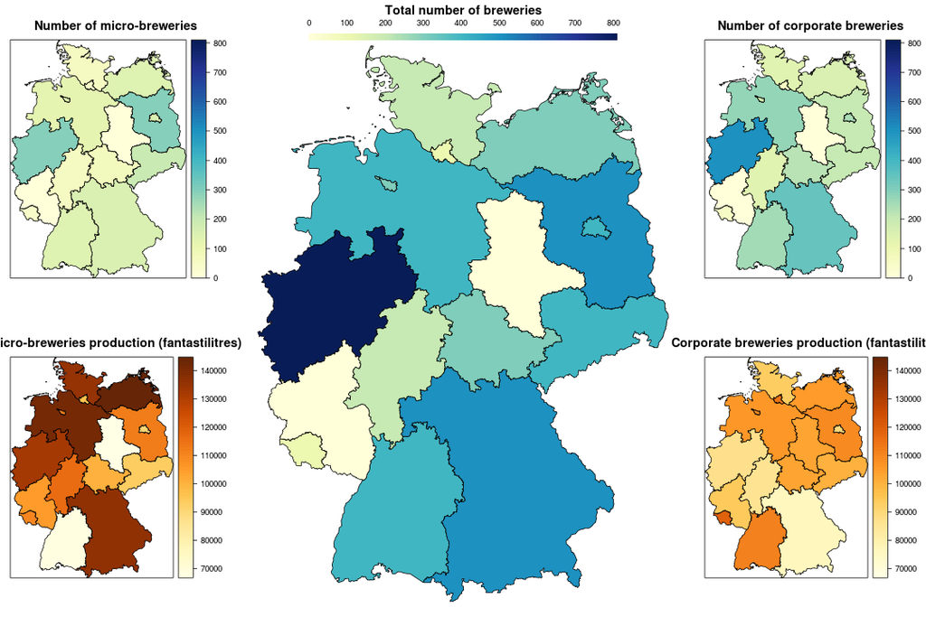

Figure 42: using packages sp, raster, RColorBrewer, and grid to create a multiple map plot

```r
### grid.newpage() clears whatever has been drawn on the device before
grid.newpage()

vp1 <- viewport(x = 0, y = 1,
                height = 0.5, width = 0.25,
                just = c("left", "top"),
                name = "upper left")
pushViewport(vp1)
print(p.micro, newpage = FALSE)

upViewport(1)

vp2 <- viewport(x = 0, y = 0,
                height = 0.5, width = 0.25,
                just = c("left", "bottom"),
                name = "lower left")
pushViewport(vp2)
print(p.micro.fl, newpage = FALSE)

upViewport(1)

vp3 <- viewport(x = 0.25, y = 0,
                height = 1, width = 0.5,
                just = c("left", "bottom"),
                name = "centre")
pushViewport(vp3)
print(p.total, newpage = FALSE)

upViewport(1)

vp4 <- viewport(x = 1, y = 1,
                height = 0.5, width = 0.25,
                just = c("right", "top"),
                name = "upper right")
pushViewport(vp4)
print(p.corpo, newpage = FALSE)

upViewport(1)
vp5 <- viewport(x = 1, y = 0,
                height = 0.5, width = 0.25,
                just = c("right", "bottom"),
                name = "lower right")
pushViewport(vp5)
print(p.corpo.fl, newpage = FALSE)

upViewport(1)
```

Nice, isn't it?

Now let's do something similar with raster data.

### 5.2. Raster data

To highlight the use of the raster package, we will use some temperature data for Germany. This can, again, be downloaded straight into the current session with `getData()`.

The steps we are taking below to produce maps of average August temperatures in Germany are as follows:

1. we get the global long-term mean temperatures from `worldclim` (these are so-called raster stacks with 12 layers, one for each month of the year - see below)
2. we crop the global data set to the extent of Germany using the gadm data set from above
3. we need to divide the temperature (which are in degrees celcius) by a factor of 10 (in order to save space, these data are stored as integers and hence multiplied by 10)
4. we download the outline of Germany from `gadm`
5. to highlight the problems related to colour representation we already touched upon in section 2.1.1. we plot 5 different representations of the same data on one page (similar to the polygon data from section 5.1.)

```r
Tmean <- getData('worldclim', var = 'tmean', res = 5)
ext <- extent(gadm)

Tmean.ger <- crop(Tmean, ext)

# worldclim stores temepratures as degrees celcius * 10
Tmean.ger <- Tmean.ger / 10

Tmean.ger
```

```
## class       : RasterBrick
## dimensions  : 94, 110, 10340, 12  (nrow, ncol, ncell, nlayers)
## resolution  : 0.08333, 0.08333  (x, y)
## extent      : 5.833, 15, 47.25, 55.08  (xmin, xmax, ymin, ymax)
## coord. ref. : +proj=longlat +datum=WGS84 +ellps=WGS84 +towgs84=0,0,0
## data source : in memory
## names       : tmean1, tmean2, tmean3, tmean4, tmean5, tmean6, tmean7, tmean8, tmean9, tmean10, tmean11, tmean12
## min values  :   -8.0,   -7.4,   -4.6,   -1.2,    3.5,    6.9,    8.9,    8.6,    5.8,     1.7,    -3.2,    -6.6
## max values  :    2.5,    3.0,    6.9,   10.4,   14.4,   17.7,   19.7,   19.2,   16.1,    11.1,     6.6,     3.9
```

The default way of plotting raster data using `spplot` is, again, not so nice - see lattice defaults.

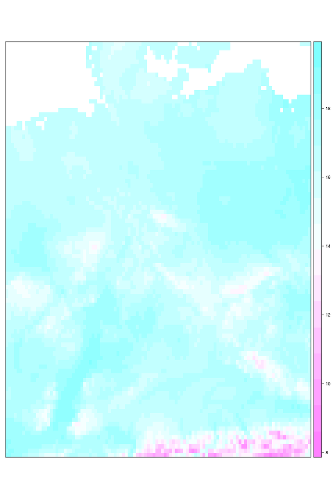

Figure 43: a basic raster plot using raster package

```r
Tplot <- spplot(Tmean.ger, zcol = "tmean8")
print(Tplot)
```

So, let's manipulate the colours a little…

```r
ger <- getData('GADM', country = 'DEU', level = 0)

Tplot.spec <- spplot(Tmean.ger, zcol = "tmean8",
                     col.regions = clrs.spec(1001),
                     cuts = 1000,
                     colorkey = list(space = "top"),
                     main = "Average August temperatures in Germany") +
  as.layer(spplot(ger, zcol = "NAME_ISO", col.regions = "transparent"))

Tplot.rnbw <- spplot(Tmean.ger, zcol = "tmean8",
                     col.regions = tim.colors(1001),
                     cuts = 1000) +
  as.layer(spplot(ger, zcol = "NAME_ISO", col.regions = "transparent"))

clrs.hcl2 <- function(n) {
  hcl(h = seq(270, 0, length.out = n),
      c = 60, l = seq(90, 40, length.out = n),
      fixup = TRUE)
  }

Tplot.hcl <- spplot(Tmean.ger, zcol = "tmean8",
                    col.regions = clrs.hcl2(1001),
                    cuts = 1000) +
  as.layer(spplot(ger, zcol = "NAME_ISO", col.regions = "transparent"))

clrs.ylorrd <- colorRampPalette(brewer.pal(9, "YlOrRd"))

Tplot.ylorrd <- spplot(Tmean.ger, zcol = "tmean8",
                       col.regions = clrs.ylorrd(1001),
                       cuts = 1000) +
  as.layer(spplot(ger, zcol = "NAME_ISO", col.regions = "transparent"))

clrs.grey <- colorRampPalette(brewer.pal(9, "Greys"))

Tplot.greys <- spplot(Tmean.ger, zcol = "tmean8",
                      col.regions = clrs.grey(1001),
                      cuts = 1000) +
  as.layer(spplot(ger, zcol = "NAME_ISO", col.regions = "transparent"))
```

Now, we can plot the different versions and compare the usefulness of the different colour palettes.

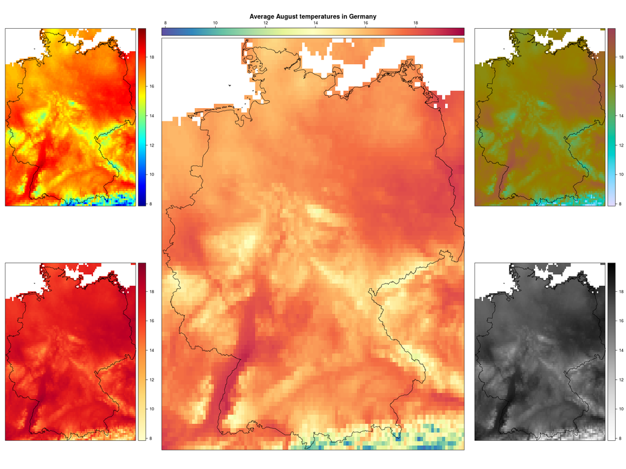

Figure 45: using packages sp, raster, RColorBrewer, and grid to create a multiple raster map plot

```r
grid.newpage()


vp1 <- viewport(x = 0, y = 1,
                height = 0.5, width = 0.25,
                just = c("left", "top"),
                name = "upper left")
pushViewport(vp1)
print(Tplot.rnbw, newpage = FALSE)

upViewport(1)

vp2 <- viewport(x = 0, y = 0,
                height = 0.5, width = 0.25,
                just = c("left", "bottom"),
                name = "lower left")
pushViewport(vp2)
print(Tplot.ylorrd, newpage = FALSE)

upViewport(1)

vp3 <- viewport(x = 0.25, y = 0,
                height = 1, width = 0.5,
                just = c("left", "bottom"),
                name = "centre")
pushViewport(vp3)
print(Tplot.spec, newpage = FALSE)

upViewport(1)

vp4 <- viewport(x = 1, y = 1,
                height = 0.5, width = 0.25,
                just = c("right", "top"),
                name = "upper right")
pushViewport(vp4)
print(Tplot.hcl, newpage = FALSE)

upViewport(1)
vp5 <- viewport(x = 1, y = 0,
                height = 0.5, width = 0.25,
                just = c("right", "bottom"),
                name = "lower right")
pushViewport(vp5)
print(Tplot.greys, newpage = FALSE)

upViewport(1)
```

Again, the `hcl` based colour palette (top right panel) seems to be the most suitable, as data distortion is minimised and at the same time it provides multiple hues which help to distinguish the temperatures in more detail than e.g. the mono-hue palettes (bottom panels). The matlab jet colour palette - here `tim.colors()` clearly shows the worst distortion by creating several artificial cold 'islands/pools', especially in the German low-mountain-ranges (in the middle of the country). The colorbrewer `Spectral` palette is acceptable in that it does not distort the data very much, yet it is technically a diverging palette which is not optimal for representing data of sequential nature.

Ok, so now we have a rather comprehensive, though far from complete (if that is even possible) set of tools for visualising our data using classical statistical plots as well as spatially mapped. I admit, that the spatial part is very limited here, but that may be part of another tutorial in the future.

I hope that this tutorial was, at least in parts, useful for some of you and that we were able to expand your skill set of producing publication quality graphics using R to some extent.

As mentioned at the beginning of this tutorial, I am happy to receive feedback, comments, criticism and bug reports at the e-mail address provided.

Cheers Tim